# Analysis of NZTA crash data

Jayden Mudge

07/05/2024

# Overview

What I don’t aim to do:

- Fully identify and resolve the root causes of all crashes in Aotearoa New Zealand

# Overview

What I don’t aim to do:

- Fully identify and resolve the root causes of all crashes in Aotearoa New Zealand

Rather, I aim to:

- Showcase my analytical skills and processes
- Outline some preliminary observations about crash rates and crash severity
- Identify possible future topics for analysis

# Initial explorations

Let’s start off by downloading the crash dataset and having a peak at what data is available in it

```
##        X                 Y              OBJECTID       advisorySpeed
##  Min.   :1150346   Min.   :4793921   Min.   :      1   Min.   :15.0
##  1st Qu.:1705075   1st Qu.:5433971   1st Qu.: 329629   1st Qu.:40.0
##  Median :1757368   Median :5803341   Median : 655346   Median :55.0
##  Mean   :1721242   Mean   :5644677   Mean   : 654113   Mean   :54.4
##  3rd Qu.:1793359   3rd Qu.:5913910   3rd Qu.: 988178   3rd Qu.:65.0
##  Max.   :2465388   Max.   :6190095   Max.   :1318963   Max.   :95.0
##                                                        NA's   :790400
##    areaUnitID        bicycle            bridge            bus
##  Min.   :500100   Min.   :0.00000   Min.   :0        Min.   :0.00000
##  1st Qu.:519400   1st Qu.:0.00000   1st Qu.:0        1st Qu.:0.00000
##  Median :536642   Median :0.00000   Median :0        Median :0.00000
##  Mean   :546242   Mean   :0.02896   Mean   :0        Mean   :0.01587
##  3rd Qu.:573523   3rd Qu.:0.00000   3rd Qu.:0        3rd Qu.:0.00000
##  Max.   :626801   Max.   :5.00000   Max.   :4        Max.   :3.00000
##  NA's   :97       NA's   :5         NA's   :488831   NA's   :5
```

# What do we find?

There’s a lot of fascinating data in here!

- X,Y co-ordinates, street names, and other geographic info
- Both calendar and financial year, and holidays if applicable
- Vehicle counts involved in crash
- Objects crashed into, where applicable
- Weather and light conditions
- Outcomes on individuals: injuries and severity

# An initial visualisation

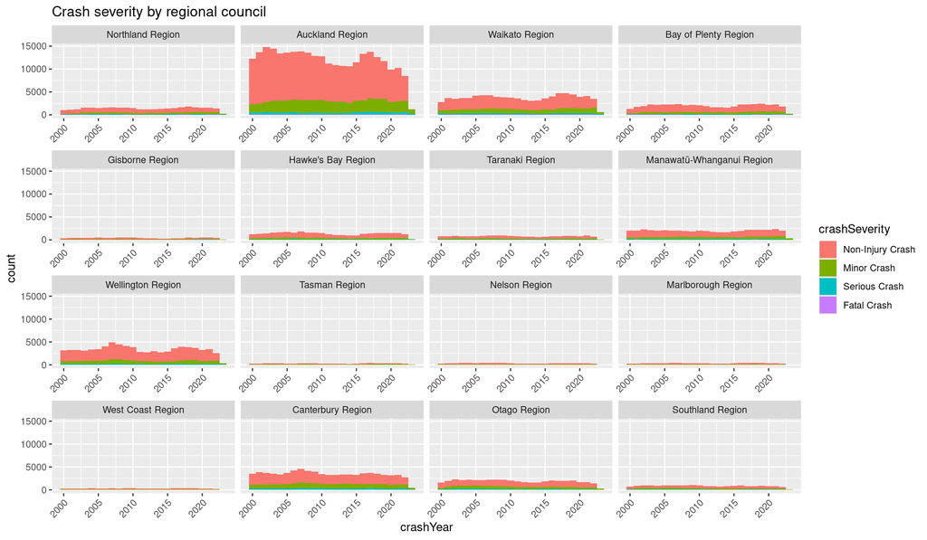

# Observations

There are some limitations with this data source.

We also seem to have incomplete data for 2023, perhaps we should drop this as it skews our analysis.

# Updated visualisation

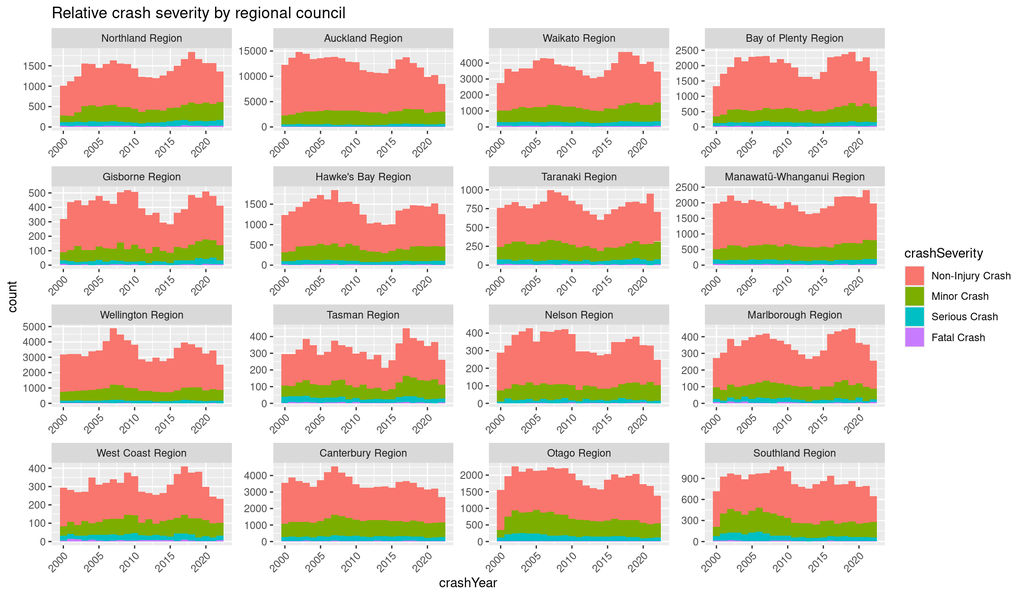

This better contrasts the severity of crashes by region. Here we can see crashes are less likely to be severe in Auckland and Wellington. However, it doesn’t resolve the crash likelihood issue. Let us say, in a region, 5% of crashes are fatal. How do we reduce that figure? We can decrease the number of fatal crashes, or we can increase the number of non-fatal crashes. Regions with a low fatality rate could actually just have a high rate of non-fatal crash obscuring the number of fatal crashes.

# Crashes involving motorbikes

A [report from NZTA](https://www.transport.govt.nz/assets/Uploads/Presentation/Overview-of-Road-Safety-in-NZ-Data-packs-for-reference-groups.pdf) noted the increase in fatalities could be driven by an increase in motorcycle registrations.

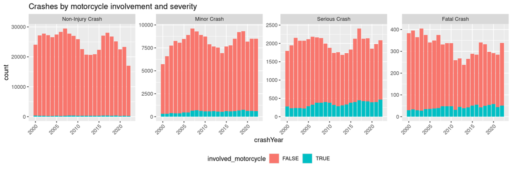

However, this doesn’t seem to be a major contributor to overall traffic collisions. We see dips from 2010-2015 for both crashes involving and not involving motorcycles, and those not involving motorcycles are clearly a larger contributor to overall crashes.

# Applying context

Using the high quality population estimates from Stats NZ, we can calculate per 1,000 usual residents for crashes at each severity level.

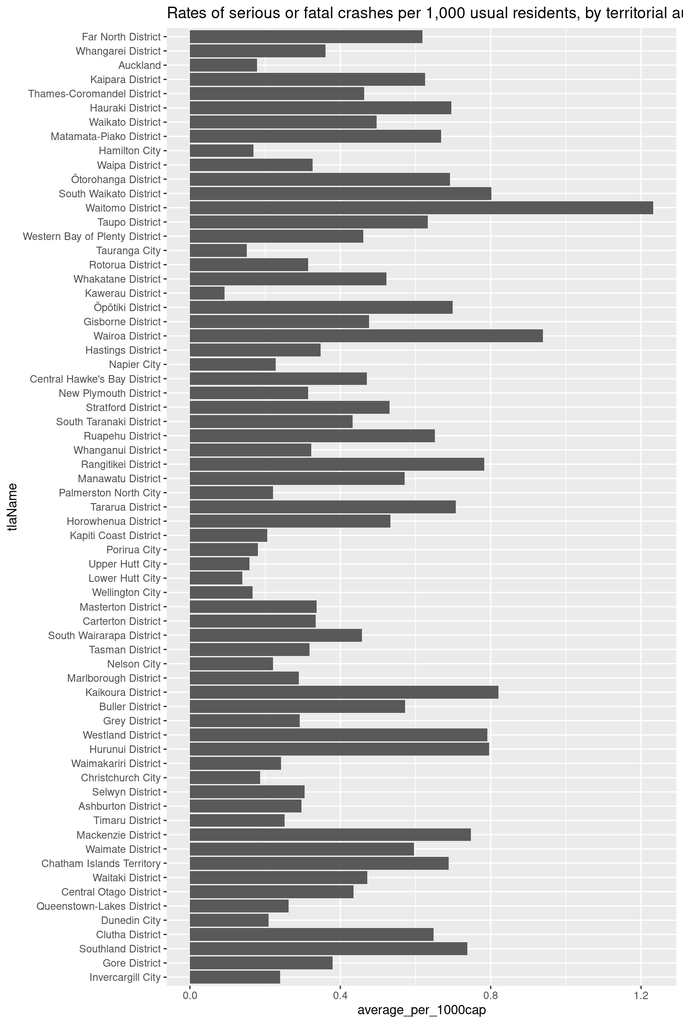

Highest crash rates per 1,000 usual residents

| tlaId | tlaName | average_per_1000cap | average_per_1000dap |
| --- | --- | --- | --- |
| 020 | Waitomo District | 1.233 | 1.572 |
| 029 | Wairoa District | 0.939 | 1.220 |
| 054 | Kaikoura District | 0.821 | 0.979 |
| 019 | South Waikato District | 0.802 | 1.038 |
| 058 | Hurunui District | 0.796 | 0.978 |
| 057 | Westland District | 0.791 | 0.944 |

Lowest crash rates per 1,000 usual residents

| tlaId | tlaName | average_per_1000cap | average_per_1000dap |
| --- | --- | --- | --- |
| 016 | Hamilton City | 0.169 | 0.214 |
| 047 | Wellington City | 0.167 | 0.196 |
| 045 | Upper Hutt City | 0.159 | 0.197 |
| 023 | Tauranga City | 0.151 | 0.188 |
| 046 | Lower Hutt City | 0.140 | 0.174 |
| 026 | Kawerau District | 0.092 | 0.120 |

I have included a per 1,000 people of driving age measure for these tables, as these are the people most likely to be behind the wheel of a car.

# Statistical modelling for significant variables

Using a Lasso regression, we can see which variables have the biggest impact of crash severity. Lasso doesn’t necessarily maximise model accuracy, but is great at filtering out which variables don’t affect crash severity, so we can then capture the important variables and put into a better model.

Positive correlation with crash severity

| var | coef |
| --- | --- |
| pedestrian | 2.275 |
| motorcycle | 2.264 |
| bicycle | 1.820 |
| moped | 1.806 |
| train | 1.573 |
| waterRiver | 0.778 |
| tree | 0.769 |
| postOrPole | 0.562 |
| otherVehicleType | 0.532 |
| bridge | 0.532 |

Negative correlation with crash severity

| var | coef |
| --- | --- |
| weatherA_Heavy rain | -0.051 |
| light_Overcast | -0.071 |
| region_Wellington Region | -0.075 |
| weatherA_Light rain | -0.086 |
| NumberOfLanes | -0.087 |
| weatherB_Frost | -0.158 |
| streetLight_Off | -0.180 |
| parkedVehicle | -0.190 |
| strayAnimal | -0.665 |
| roadLane_1-way | -0.838 |

```
## [1] "Low correlation with crash severity"
```

[output not shown]

It appears as though people not inside a vehicle correlate most strongly with high severity crashes. This doesn’t confirm they are the recipients of the severe injuries, but it stands to reason. In contrast, crashes involving a train are probably more severe for the person on the other end.

We also see bridges, rivers, and bodies of water as high correlates with severity, which makes a lot of sense. Trees, posts, and poles could be because they’re quite sturdy objects, so crashing into them means you come to a more sudden halt than if you crash into a fence, house, or animal.

# Ideas for further exploration

- Link in traffic volumes - NZTA measure this for major roads, Auckland Transport measure for Auckland roads. This can help us identify which roads are disproportionately dangerous
- Could look at census usual mode of travel to work to estimate cyclist volumes against bicycle related crashes
- If we find a way to get time-of-day data or estimate it, I’d be interested to explore crash rates for people driving into the sun (East in the morning, West in the evening)
- Also if time of day has an impact more generally on crash likelihood and severity (after accounting for light conditions)
- Who is responsible in these crashes? Do cars need to be more mindful of pedestrians and (motor)cyclists, or do pedestrians and cyclists need to be more careful?
- Why *did* crashes of all severity levels dip from 2010 - 2015?

# Actions

- Consult with subject matter and policy experts
- Policy, information campaigns to protect pedestrians and cyclists - or to teach pedestrians and cyclists how to stay safe on the road
- Information campaigns for surviving crashing into bodies of water
- Transform footpaths to make them safer for pedestrians
- Airbags for trees? - Maybe not!

# Thank you for your attention

Pātai - any questions?